# Supervised_Learning_Regression_Models

```python
# Computations
import numpy as np
import pandas as pd
from scipy.stats import norm
from scipy import stats
import statsmodels.formula.api as smf

# Progressbar
import progressbar

# sklearn data
import sklearn
from sklearn.datasets import load_boston
from sklearn.metrics import mean_squared_error, r2_score

# Train and Test sets splitting
from sklearn.model_selection import train_test_split

# Regressors
from sklearn import linear_model
from sklearn.tree import DecisionTreeRegressor
from sklearn.ensemble import GradientBoostingRegressor
from sklearn.model_selection import GridSearchCV
from sklearn.neighbors import KNeighborsClassifier
from sklearn import metrics
from sklearn.kernel_ridge import KernelRidge
from sklearn.neural_network import MLPRegressor
from sklearn.ensemble import BaggingRegressor
from sklearn.ensemble import AdaBoostRegressor
from sklearn.ensemble import RandomForestRegressor
from sklearn.multioutput import MultiOutputClassifier


# Visualisation libraries

## Text
from colorama import Fore, Back, Style
from IPython.display import display, Markdown, Latex

## seaborn
import seaborn as sns
sns.set_context("paper", rc={"font.size":12,"axes.titlesize":14,"axes.labelsize":12})
sns.set_style("whitegrid")

## matplotlib
import matplotlib.pyplot as plt
from matplotlib.patches import Ellipse, Polygon
import matplotlib.gridspec as gridspec
plt.style.use('seaborn-whitegrid')
plt.rcParams['axes.labelsize'] = 14
plt.rcParams['xtick.labelsize'] = 12
plt.rcParams['ytick.labelsize'] = 12
plt.rcParams['text.color'] = 'k'
%matplotlib inline

import warnings
warnings.filterwarnings("ignore")
```

- Dataset
- Data Exploration
- Generalized Linear Models
  - Ordinary Least Squares
  - Ridge
  - Lasso
  - Elastic-Net
  - Least Angle Regressions (LARS))
  - LARS Lasso
  - Orthogonal Matching Pursuit
  - Bayesian Regression
  - Huber Regressor
  - Random Sample Consensus (RANSAC))
- Other Models
  - Kernel Ridge Regression
  - Neural Network Regression Model (Supervised))
  - Decision Tree Regression
  - Gradient Boosted Tree
  - Ada Boost Regressor
  - Random Forest Regressor
  - Bagging Regressor
- Conclusion

# Dataset

Attribute Information (in order):

| Attribute | Attribute Information |
| --- | --- |
| CRIM | per capita crime rate by town |
| ZN | proportion of residential land zoned for lots over 25,000 sq.ft. |
| INDUS | proportion of non-retail business acres per town |
| CHAS | Charles River dummy variable (= 1 if tract bounds river; 0 otherwise) |
| NOX | nitric oxides concentration (parts per 10 million) |
| RM | average number of rooms per dwelling |
| AGE | proportion of owner-occupied units built prior to 1940 |
| DIS | weighted distances to five Boston employment centres |
| RAD | index of accessibility to radial highways |
| TAX | full-value property-tax rate per $\$10,000$ |
| PTRATIO | pupil-teacher ratio by town |
| B | $1000(Bk - 0.63)^2$ where Bk is the proportion of blacks by town |
| LSTAT | $\%$ lower status of the population |
| MEDV | Median value of owner-occupied homes in $\$1000$’s |

Source:

- https://scikit-learn.org/stable/datasets/index.html
- https://archive.ics.uci.edu/ml/machine-learning-databases/housing/

```python
# Loading the dataset from sklearn datasets
Temp = load_boston()
Data = pd.DataFrame(Temp.data)
Data.columns = Temp.feature_names
del Temp
# Adding MEDV column from the original source
Temp = pd.read_csv('https://archive.ics.uci.edu/ml/machine-learning-databases/housing/housing.data',
                   delimiter= '\s+', index_col=False, header=None)
Data['MEDV'] = Temp.iloc[:,-1]
del Temp
# Saving as a CSV file
Data.to_csv('Data/Housing_Data.csv',index=False)
# The Dataset
Data.head().style.hide_index()
```

| CRIM | ZN | INDUS | CHAS | NOX | RM | AGE | DIS | RAD | TAX | PTRATIO | B | LSTAT | MEDV |
| --- | --- | --- | --- | --- | --- | --- | --- | --- | --- | --- | --- | --- | --- |
| 0.006320 | 18.000000 | 2.310000 | 0.000000 | 0.538000 | 6.575000 | 65.200000 | 4.090000 | 1.000000 | 296.000000 | 15.300000 | 396.900000 | 4.980000 | 24.000000 |
| 0.027310 | 0.000000 | 7.070000 | 0.000000 | 0.469000 | 6.421000 | 78.900000 | 4.967100 | 2.000000 | 242.000000 | 17.800000 | 396.900000 | 9.140000 | 21.600000 |
| 0.027290 | 0.000000 | 7.070000 | 0.000000 | 0.469000 | 7.185000 | 61.100000 | 4.967100 | 2.000000 | 242.000000 | 17.800000 | 392.830000 | 4.030000 | 34.700000 |
| 0.032370 | 0.000000 | 2.180000 | 0.000000 | 0.458000 | 6.998000 | 45.800000 | 6.062200 | 3.000000 | 222.000000 | 18.700000 | 394.630000 | 2.940000 | 33.400000 |
| 0.069050 | 0.000000 | 2.180000 | 0.000000 | 0.458000 | 7.147000 | 54.200000 | 6.062200 | 3.000000 | 222.000000 | 18.700000 | 396.900000 | 5.330000 | 36.200000 |

```python
Data.describe()
```

|  | CRIM | ZN | INDUS | CHAS | NOX | RM | AGE | DIS | RAD | TAX | PTRATIO | B | LSTAT | MEDV |
| --- | --- | --- | --- | --- | --- | --- | --- | --- | --- | --- | --- | --- | --- | --- |
| count | 506.000000 | 506.000000 | 506.000000 | 506.000000 | 506.000000 | 506.000000 | 506.000000 | 506.000000 | 506.000000 | 506.000000 | 506.000000 | 506.000000 | 506.000000 | 506.000000 |
| mean | 3.613524 | 11.363636 | 11.136779 | 0.069170 | 0.554695 | 6.284634 | 68.574901 | 3.795043 | 9.549407 | 408.237154 | 18.455534 | 356.674032 | 12.653063 | 22.532806 |
| std | 8.601545 | 23.322453 | 6.860353 | 0.253994 | 0.115878 | 0.702617 | 28.148861 | 2.105710 | 8.707259 | 168.537116 | 2.164946 | 91.294864 | 7.141062 | 9.197104 |
| min | 0.006320 | 0.000000 | 0.460000 | 0.000000 | 0.385000 | 3.561000 | 2.900000 | 1.129600 | 1.000000 | 187.000000 | 12.600000 | 0.320000 | 1.730000 | 5.000000 |
| 25% | 0.082045 | 0.000000 | 5.190000 | 0.000000 | 0.449000 | 5.885500 | 45.025000 | 2.100175 | 4.000000 | 279.000000 | 17.400000 | 375.377500 | 6.950000 | 17.025000 |
| 50% | 0.256510 | 0.000000 | 9.690000 | 0.000000 | 0.538000 | 6.208500 | 77.500000 | 3.207450 | 5.000000 | 330.000000 | 19.050000 | 391.440000 | 11.360000 | 21.200000 |
| 75% | 3.677083 | 12.500000 | 18.100000 | 0.000000 | 0.624000 | 6.623500 | 94.075000 | 5.188425 | 24.000000 | 666.000000 | 20.200000 | 396.225000 | 16.955000 | 25.000000 |
| max | 88.976200 | 100.000000 | 27.740000 | 1.000000 | 0.871000 | 8.780000 | 100.000000 | 12.126500 | 24.000000 | 711.000000 | 22.000000 | 396.900000 | 37.970000 | 50.000000 |

# Data Exploration

First, let's define some functions.

```python
def High_Correlated_Attributes(Df, threshold = 0.5):
    Correlation_Matrix = Df.corr()
    Temp = Correlation_Matrix[Correlation_Matrix>= threshold]
    Temp1 = Temp.notnull().sum()
    Temp1 = Temp1[Temp1 == Temp1.max()].index.tolist()[0]
    Temp = Temp[Temp1].dropna()
    mylist = Temp.index.tolist()
    return mylist
```

```python
def Correlation_Plot (Df,Fig_Size):
    Correlation_Matrix = Df.corr().round(2)
    mask = np.zeros_like(Correlation_Matrix)
    mask[np.triu_indices_from(mask)] = True
    for i in range(len(mask)):
        mask[i,i]=0
    Fig, ax = plt.subplots(figsize=(Fig_Size,Fig_Size))
    sns.heatmap(Correlation_Matrix, ax=ax, mask=mask, annot=True, square=True,
                cmap =sns.color_palette("RdYlGn", n_colors=10), linewidths = 0.2, vmin=0, vmax=1, cbar_kws={"shrink": .5})
    bottom, top = ax.get_ylim()
    ax.set_ylim(bottom + 0.5, top - 0.5)
```

```python
# Highly correlated attributes:
Temp = Data[High_Correlated_Attributes(Data)]
```

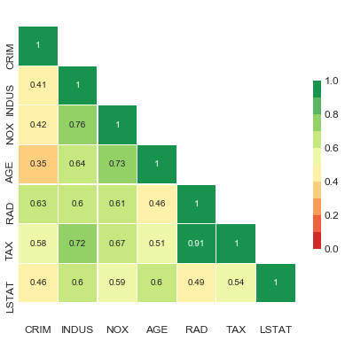

```python
Correlation_Plot (Temp,len(High_Correlated_Attributes(Data)))
```

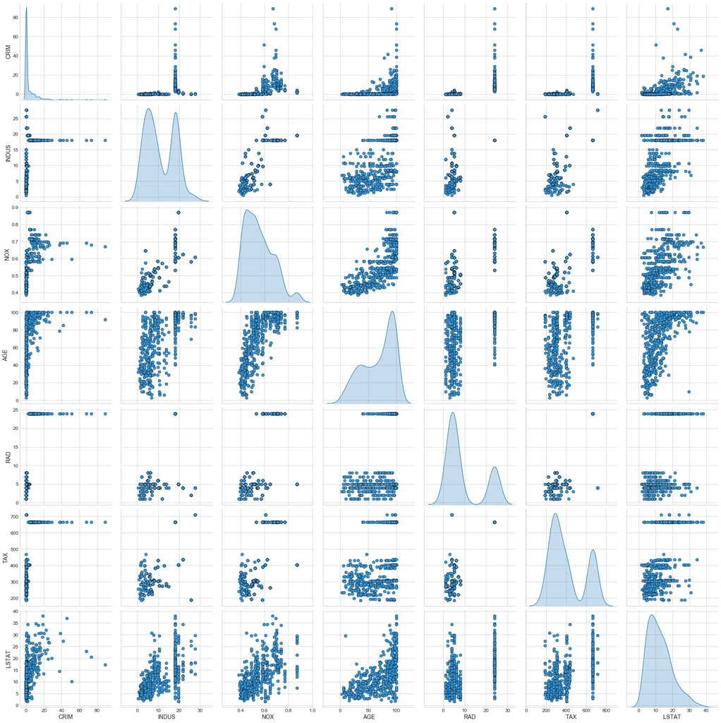

```python
_ = sns.pairplot(Temp, height=3.5,diag_kind="kde",
                 plot_kws=dict(s=50, color="#3498db", edgecolor="k", linewidth=0.5),diag_kws=dict(shade=True))
```

A univariate distribution of observations:

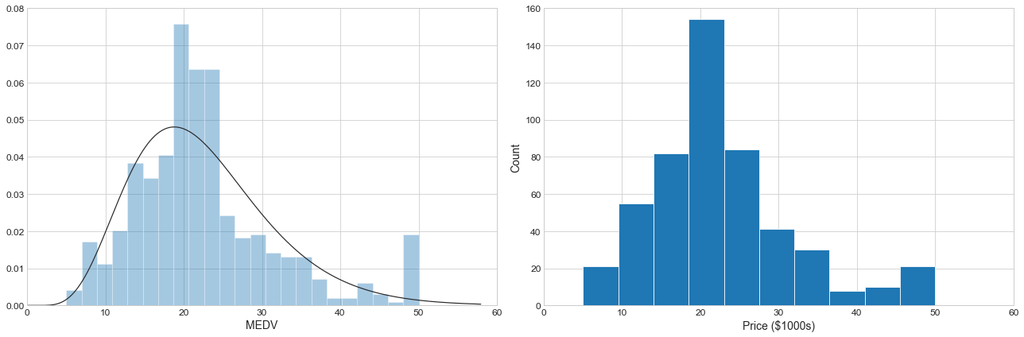

```python
fig, ax = plt.subplots(1,2, figsize=(18,6))
_ = sns.distplot(Data.MEDV, kde=False, fit=stats.gamma, ax=ax[0])
_ = ax[0].set_xlim([0, 60])
_ = ax[0].set_ylim([0, 0.08])

_ = ax[1].hist(Data.MEDV)
_ = ax[1].set_xlabel('Price ($1000s)')
_ = ax[1].set_ylabel('Count')
_ = ax[1].set_xlim([0, 60])
_ = ax[1].set_ylim([0, 160])

plt.tight_layout()
```

# Train and Test Sets

```python
X = Data.drop(columns='MEDV')
y = Data.MEDV
X_train, X_test, y_train, y_test = train_test_split(X, y, test_size=0.3, random_state=42)
pd.DataFrame(data={'Set':['X_train','X_test','y_train','y_test'],
               'Shape':[X_train.shape, X_test.shape, y_train.shape, y_test.shape]}).set_index('Set').T
```

| Set | X_train | X_test | y_train | y_test |
| --- | --- | --- | --- | --- |
| Shape | (354, 13) | (152, 13) | (354,) | (152,) |

In the next section, we use the following function for plotting.

```python
def Plot_Reg_Results(Expected, Predicted, Reg):
    fig, ax = plt.subplots(figsize=(10,5))
    _ = ax.scatter(Expected, Predicted)
    N = int(np.max(np.ceil([np.max(Expected), np.max(Predicted)])))+10
    _ = ax.plot([0, N], [0, N], '--k')
    _ = ax.set_xlabel('True price ($1000s)', fontsize=14)
    _ = ax.set_ylabel('Predicted price ($1000s)', fontsize=14)
    _ = ax.set_xlim([0, N])
    _ = ax.set_ylim([0, N])

    plt.tight_layout()
```

Moreover, we can create a table for later comparisons.

```python
Results = pd.DataFrame(data={'Regression': ['Ordinary Least Squares'],'Score':'', 'MSE':'', 'Variance score':''})
Results = Results.set_index('Regression')
```

Next, we compare several regression models in terms of score, MSE, and Variance score.

# Generalized Linear Models

## Ordinary Least Squares

```python
Reg = 'Ordinary Least Squares'
clf = linear_model.LinearRegression()

# the model
clf.fit(X_train, y_train)

# Predicted Values
Predicted = clf.predict(X_test)
# Expected Values
Expected = y_test

# the plot
Plot_Reg_Results(Expected, Predicted, Reg)

# the table
Results.loc[Reg,:] = [clf.score(X_test, y_test), mean_squared_error(Expected, Predicted), r2_score(Expected, Predicted)]
display(Results.style.background_gradient(cmap='Greens', subset=['Score']).set_precision(2))
```

[output not shown]

| Regression | Score | MSE | Variance score |
| --- | --- | --- | --- |
| Ordinary Least Squares | 0.71 | 21.52 | 0.71 |

## Ridge

The parameter $\alpha$ = 0.0345

| Regression | Score | MSE | Variance score |
| --- | --- | --- | --- |
| Ordinary Least Squares | 0.71 | 21.52 | 0.71 |
| Ridge | 0.71 | 21.54 | 0.71 |

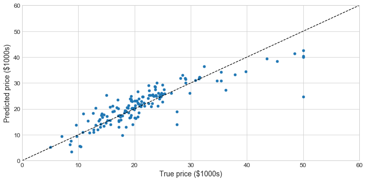

```python
clf = linear_model.RidgeCV(alphas=np.logspace(-3, 3, 200))
clf.fit(X_train, y_train)
display(Latex(r'The parameter $\alpha$ = %.4f' % clf.alpha_))

Reg = 'Ridge'

# Predicted Values
Predicted = clf.predict(X_test)
# Expected Values
Expected = y_test

# the plot
Plot_Reg_Results(Expected, Predicted, Reg)

# the table
Results.loc[Reg,:] = [clf.score(X_test, y_test), mean_squared_error(Expected, Predicted),
                                      r2_score(Expected, Predicted)]
display(Results.style.background_gradient(cmap='Greens', subset=['Score']).set_precision(2))
```

## Lasso

The parameter $\alpha$ = 0.0010

| Regression | Score | MSE | Variance score |
| --- | --- | --- | --- |
| Ordinary Least Squares | 0.71 | 21.52 | 0.71 |
| Ridge | 0.71 | 21.54 | 0.71 |
| Lasso | 0.71 | 21.53 | 0.71 |

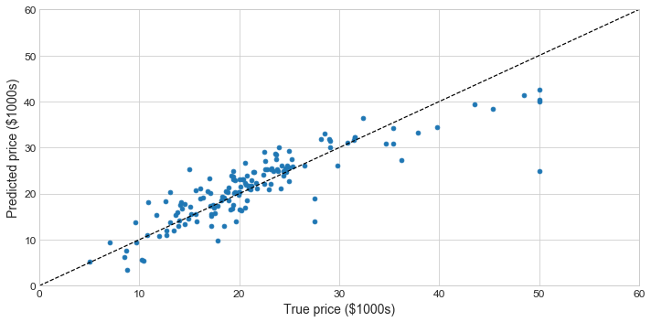

```python
clf = linear_model.LassoCV(alphas=np.logspace(-3, 3, 200))
clf.fit(X_train, y_train)

display(Latex(r'The parameter $\alpha$ = %.4f' % clf.alpha_))

Reg = 'Lasso'

# Predicted Values
Predicted = clf.predict(X_test)
# Expected Values
Expected = y_test

# the plot
Plot_Reg_Results(Expected, Predicted, Reg)

# the table
Results.loc[Reg,:] = [clf.score(X_test, y_test), mean_squared_error(Expected, Predicted),
                                      r2_score(Expected, Predicted)]
display(Results.style.background_gradient(cmap='Greens', subset=['Score']).set_precision(2))
```

## Elastic-Net

| Regression | Score | MSE | Variance score |
| --- | --- | --- | --- |
| Ordinary Least Squares | 0.71 | 21.52 | 0.71 |
| Ridge | 0.71 | 21.54 | 0.71 |
| Lasso | 0.71 | 21.53 | 0.71 |
| Elastic-Net | 0.66 | 25.41 | 0.66 |

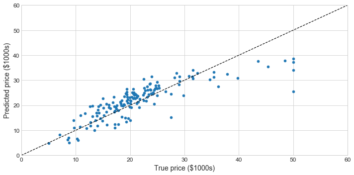

```python
Reg = 'Elastic-Net'

clf = linear_model.ElasticNet(random_state=0)
clf.fit(X_train, y_train)

# Predicted Values
Predicted = clf.predict(X_test)
# Expected Values
Expected = y_test

# the plot
Plot_Reg_Results(Expected, Predicted, Reg)

# the table
Results.loc[Reg,:] = [clf.score(X_test, y_test), mean_squared_error(Expected, Predicted),
                                      r2_score(Expected, Predicted)]
display(Results.style.background_gradient(cmap='Greens', subset=['Score']).set_precision(2))
```

## Least Angle Regressions (LARS)

```python
Reg = 'Least Angle Regressions (LARS)'

clf = linear_model.Lars(n_nonzero_coefs = len(X_train.columns))
clf.fit(X_train, y_train)

# Predicted Values
Predicted = clf.predict(X_test)
# Expected Values
Expected = y_test

# the plot
Plot_Reg_Results(Expected, Predicted, Reg)

# the table
Results.loc[Reg,:] = [clf.score(X_test, y_test), mean_squared_error(Expected, Predicted),
                                      r2_score(Expected, Predicted)]
display(Results.style.background_gradient(cmap='Greens', subset=['Score']).set_precision(2))
```

[output not shown]

| Regression | Score | MSE | Variance score |
| --- | --- | --- | --- |
| Ordinary Least Squares | 0.71 | 21.52 | 0.71 |
| Ridge | 0.71 | 21.54 | 0.71 |
| Lasso | 0.71 | 21.53 | 0.71 |
| Elastic-Net | 0.66 | 25.41 | 0.66 |
| Least Angle Regressions (LARS) | 0.71 | 21.52 | 0.71 |

## LARS Lasso

| Regression | Score | MSE | Variance score |
| --- | --- | --- | --- |
| Ordinary Least Squares | 0.71 | 21.52 | 0.71 |
| Ridge | 0.71 | 21.54 | 0.71 |
| Lasso | 0.71 | 21.53 | 0.71 |
| Elastic-Net | 0.66 | 25.41 | 0.66 |
| Least Angle Regressions (LARS) | 0.71 | 21.52 | 0.71 |
| LARS Lasso | 0.71 | 21.62 | 0.71 |

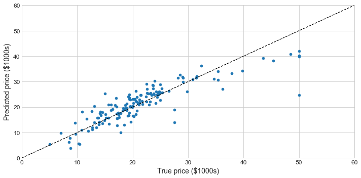

```python
Reg = 'LARS Lasso'

clf = linear_model.LassoLars(alpha=.001)
clf.fit(X_train, y_train)

# Predicted Values
Predicted = clf.predict(X_test)
# Expected Values
Expected = y_test

# the plot
Plot_Reg_Results(Expected, Predicted, Reg)

# the table
Results.loc[Reg,:] = [clf.score(X_test, y_test), mean_squared_error(Expected, Predicted),
                                      r2_score(Expected, Predicted)]
display(Results.style.background_gradient(cmap='Greens', subset=['Score']).set_precision(2))
```

## Orthogonal Matching Pursuit

```python
Reg = 'Orthogonal Matching Pursuit'

clf = linear_model.OrthogonalMatchingPursuit(n_nonzero_coefs= len(X_train.columns))
clf.fit(X_train, y_train)

# Predicted Values
Predicted = clf.predict(X_test)
# Expected Values
Expected = y_test

# the plot
Plot_Reg_Results(Expected, Predicted, Reg)

# the table
Results.loc[Reg,:] = [clf.score(X_test, y_test), mean_squared_error(Expected, Predicted),
                                      r2_score(Expected, Predicted)]
display(Results.style.background_gradient(cmap='Greens', subset=['Score']).set_precision(2))
```

[output not shown]

| Regression | Score | MSE | Variance score |
| --- | --- | --- | --- |
| Ordinary Least Squares | 0.71 | 21.52 | 0.71 |
| Ridge | 0.71 | 21.54 | 0.71 |
| Lasso | 0.71 | 21.53 | 0.71 |
| Elastic-Net | 0.66 | 25.41 | 0.66 |
| Least Angle Regressions (LARS) | 0.71 | 21.52 | 0.71 |
| LARS Lasso | 0.71 | 21.62 | 0.71 |
| Orthogonal Matching Pursuit | 0.71 | 21.52 | 0.71 |

## Bayesian Regression

| Regression | Score | MSE | Variance score |
| --- | --- | --- | --- |
| Ordinary Least Squares | 0.71 | 21.52 | 0.71 |
| Ridge | 0.71 | 21.54 | 0.71 |
| Lasso | 0.71 | 21.53 | 0.71 |
| Elastic-Net | 0.66 | 25.41 | 0.66 |
| Least Angle Regressions (LARS) | 0.71 | 21.52 | 0.71 |
| LARS Lasso | 0.71 | 21.62 | 0.71 |
| Orthogonal Matching Pursuit | 0.71 | 21.52 | 0.71 |
| Bayesian Regression | 0.69 | 22.73 | 0.69 |

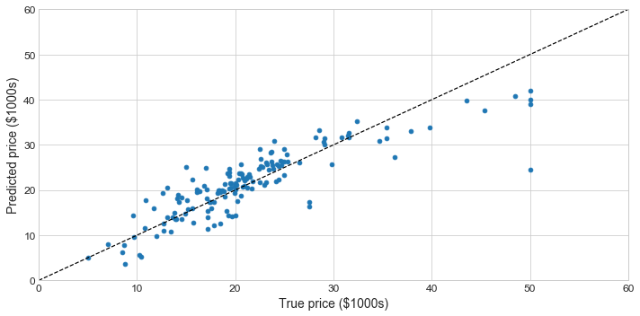

```python
Reg = 'Bayesian Regression'

clf = linear_model.BayesianRidge()
clf.fit(X_train, y_train)

# Predicted Values
Predicted = clf.predict(X_test)
# Expected Values
Expected = y_test

# the plot
Plot_Reg_Results(Expected, Predicted, Reg)

# the table
Results.loc[Reg,:] = [clf.score(X_test, y_test), mean_squared_error(Expected, Predicted),
                                      r2_score(Expected, Predicted)]
display(Results.style.background_gradient(cmap='Greens', subset=['Score']).set_precision(2))
```

## Huber Regressor

| Regression | Score | MSE | Variance score |
| --- | --- | --- | --- |
| Ordinary Least Squares | 0.71 | 21.52 | 0.71 |
| Ridge | 0.71 | 21.54 | 0.71 |
| Lasso | 0.71 | 21.53 | 0.71 |
| Elastic-Net | 0.66 | 25.41 | 0.66 |
| Least Angle Regressions (LARS) | 0.71 | 21.52 | 0.71 |
| LARS Lasso | 0.71 | 21.62 | 0.71 |
| Orthogonal Matching Pursuit | 0.71 | 21.52 | 0.71 |
| Bayesian Regression | 0.69 | 22.73 | 0.69 |
| Huber Regressor | 0.65 | 26.38 | 0.65 |

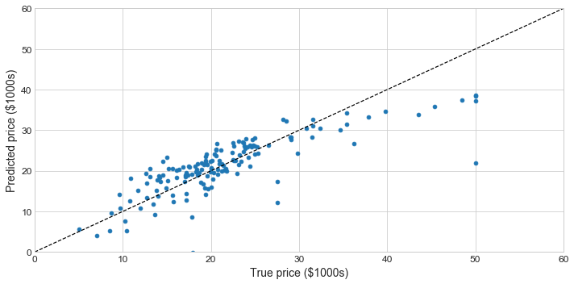

```python
Reg = 'Huber Regressor'

clf = linear_model.HuberRegressor()
clf.fit(X_train, y_train)

# Predicted Values
Predicted = clf.predict(X_test)
# Expected Values
Expected = y_test

# the plot
Plot_Reg_Results(Expected, Predicted, Reg)

# the table
Results.loc[Reg,:] = [clf.score(X_test, y_test), mean_squared_error(Expected, Predicted),
                                      r2_score(Expected, Predicted)]
display(Results.style.background_gradient(cmap='Greens', subset=['Score']).set_precision(2))
```

## Random Sample Consensus (RANSAC)

| Regression | Score | MSE | Variance score |
| --- | --- | --- | --- |
| Ordinary Least Squares | 0.71 | 21.52 | 0.71 |
| Ridge | 0.71 | 21.54 | 0.71 |
| Lasso | 0.71 | 21.53 | 0.71 |
| Elastic-Net | 0.66 | 25.41 | 0.66 |
| Least Angle Regressions (LARS) | 0.71 | 21.52 | 0.71 |
| LARS Lasso | 0.71 | 21.62 | 0.71 |
| Orthogonal Matching Pursuit | 0.71 | 21.52 | 0.71 |
| Bayesian Regression | 0.69 | 22.73 | 0.69 |
| Huber Regressor | 0.65 | 26.38 | 0.65 |
| RANSAC | 0.64 | 27.15 | 0.64 |

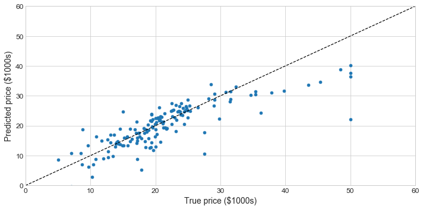

```python
Reg = 'RANSAC'

clf = linear_model.RANSACRegressor()
clf.fit(X_train, y_train)

# Predicted Values
Predicted = clf.predict(X_test)
# Expected Values
Expected = y_test

# the plot
Plot_Reg_Results(Expected, Predicted, Reg)

# the table
Results.loc[Reg,:] = [clf.score(X_test, y_test), mean_squared_error(Expected, Predicted),
                                      r2_score(Expected, Predicted)]
display(Results.style.background_gradient(cmap='Greens', subset=['Score']).set_precision(2))
```

# Other Models

## Kernel Ridge Regression

| Regression | Score | MSE | Variance score |
| --- | --- | --- | --- |
| Ordinary Least Squares | 0.71 | 21.52 | 0.71 |
| Ridge | 0.71 | 21.54 | 0.71 |
| Lasso | 0.71 | 21.53 | 0.71 |
| Elastic-Net | 0.66 | 25.41 | 0.66 |
| Least Angle Regressions (LARS) | 0.71 | 21.52 | 0.71 |
| LARS Lasso | 0.71 | 21.62 | 0.71 |
| Orthogonal Matching Pursuit | 0.71 | 21.52 | 0.71 |
| Bayesian Regression | 0.69 | 22.73 | 0.69 |
| Huber Regressor | 0.65 | 26.38 | 0.65 |
| RANSAC | 0.64 | 27.15 | 0.64 |
| Kernel Ridge Regression | 0.67 | 24.89 | 0.67 |

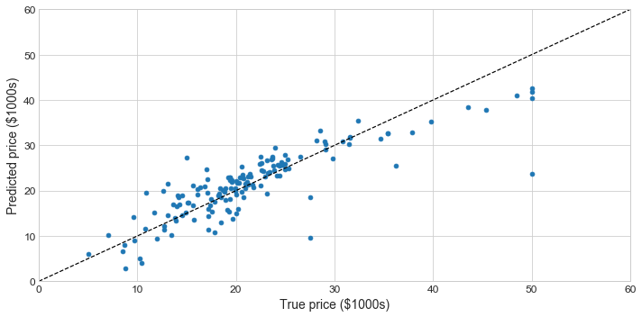

```python
Reg = 'Kernel Ridge Regression'

clf = KernelRidge(alpha=1.0)
clf.fit(X_train, y_train)

# Predicted Values
Predicted = clf.predict(X_test)
# Expected Values
Expected = y_test

# the plot
Plot_Reg_Results(Expected, Predicted, Reg)

# the table
Results.loc[Reg,:] = [clf.score(X_test, y_test), mean_squared_error(Expected, Predicted),
                                      r2_score(Expected, Predicted)]
display(Results.style.background_gradient(cmap='Greens', subset=['Score']).set_precision(2))
```

## Neural Network Regression Model (Supervised)

| Regression | Score | MSE | Variance score |
| --- | --- | --- | --- |
| Ordinary Least Squares | 0.71 | 21.52 | 0.71 |
| Ridge | 0.71 | 21.54 | 0.71 |
| Lasso | 0.71 | 21.53 | 0.71 |
| Elastic-Net | 0.66 | 25.41 | 0.66 |
| Least Angle Regressions (LARS) | 0.71 | 21.52 | 0.71 |
| LARS Lasso | 0.71 | 21.62 | 0.71 |
| Orthogonal Matching Pursuit | 0.71 | 21.52 | 0.71 |
| Bayesian Regression | 0.69 | 22.73 | 0.69 |
| Huber Regressor | 0.65 | 26.38 | 0.65 |
| RANSAC | 0.64 | 27.15 | 0.64 |
| Kernel Ridge Regression | 0.67 | 24.89 | 0.67 |
| MLP Regressor | 0.65 | 26.42 | 0.65 |

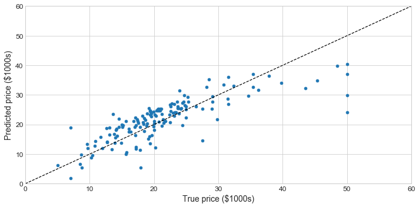

```python
Reg = 'MLP Regressor'

clf = MLPRegressor()
clf.fit(X_train, y_train)

# Predicted Values
Predicted = clf.predict(X_test)
# Expected Values
Expected = y_test

# the plot
Plot_Reg_Results(Expected, Predicted, Reg)

# the table
Results.loc[Reg,:] = [clf.score(X_test, y_test), mean_squared_error(Expected, Predicted),
                                      r2_score(Expected, Predicted)]
display(Results.style.background_gradient(cmap='Greens', subset=['Score']).set_precision(2))
```

## Decision Tree Regression

| Regression | Score | MSE | Variance score |
| --- | --- | --- | --- |
| Ordinary Least Squares | 0.71 | 21.52 | 0.71 |
| Ridge | 0.71 | 21.54 | 0.71 |
| Lasso | 0.71 | 21.53 | 0.71 |
| Elastic-Net | 0.66 | 25.41 | 0.66 |
| Least Angle Regressions (LARS) | 0.71 | 21.52 | 0.71 |
| LARS Lasso | 0.71 | 21.62 | 0.71 |
| Orthogonal Matching Pursuit | 0.71 | 21.52 | 0.71 |
| Bayesian Regression | 0.69 | 22.73 | 0.69 |
| Huber Regressor | 0.65 | 26.38 | 0.65 |
| RANSAC | 0.64 | 27.15 | 0.64 |
| Kernel Ridge Regression | 0.67 | 24.89 | 0.67 |
| MLP Regressor | 0.65 | 26.42 | 0.65 |
| Decision Tree Regression | 0.85 | 11.01 | 0.85 |

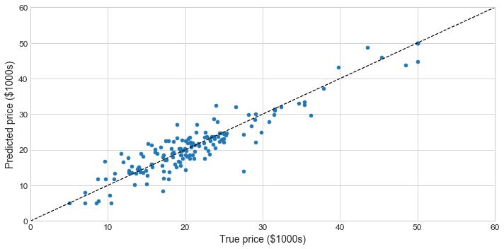

```python
Reg = 'Decision Tree Regression'

clf = DecisionTreeRegressor()
clf.fit(X_train, y_train)

# Predicted Values
Predicted = clf.predict(X_test)
# Expected Values
Expected = y_test

# the plot
Plot_Reg_Results(Expected, Predicted, Reg)

# the table
Results.loc[Reg,:] = [clf.score(X_test, y_test), mean_squared_error(Expected, Predicted),
                                      r2_score(Expected, Predicted)]
display(Results.style.background_gradient(cmap='Greens', subset=['Score']).set_precision(2))
```

## Gradient Boosted Tree

We also can use the Gradient Boosting Regressor.

| Regression | Score | MSE | Variance score |
| --- | --- | --- | --- |
| Ordinary Least Squares | 0.71 | 21.52 | 0.71 |
| Ridge | 0.71 | 21.54 | 0.71 |
| Lasso | 0.71 | 21.53 | 0.71 |
| Elastic-Net | 0.66 | 25.41 | 0.66 |
| Least Angle Regressions (LARS) | 0.71 | 21.52 | 0.71 |
| LARS Lasso | 0.71 | 21.62 | 0.71 |
| Orthogonal Matching Pursuit | 0.71 | 21.52 | 0.71 |
| Bayesian Regression | 0.69 | 22.73 | 0.69 |
| Huber Regressor | 0.65 | 26.38 | 0.65 |
| RANSAC | 0.64 | 27.15 | 0.64 |
| Kernel Ridge Regression | 0.67 | 24.89 | 0.67 |
| MLP Regressor | 0.65 | 26.42 | 0.65 |
| Decision Tree Regression | 0.85 | 11.01 | 0.85 |
| Gradient Boosted Tree | 0.89 | 8.14 | 0.89 |

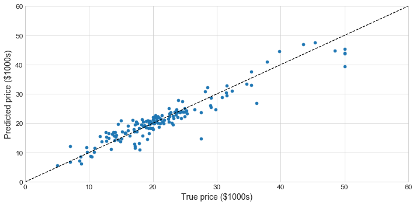

```python
Reg = 'Gradient Boosted Tree'

clf = GradientBoostingRegressor()
clf.fit(X_train, y_train)

# Predicted Values
Predicted = clf.predict(X_test)
# Expected Values
Expected = y_test

# the plot
Plot_Reg_Results(Expected, Predicted, Reg)

# the table
Results.loc[Reg,:] = [clf.score(X_test, y_test), mean_squared_error(Expected, Predicted),
                                      r2_score(Expected, Predicted)]
display(Results.style.background_gradient(cmap='Greens', subset=['Score']).set_precision(2))
```

## Ada Boost Regressor

See more about [Ada Boost Regressor](https://scikit-learn.org/stable/modules/generated/sklearn.ensemble.AdaBoostRegressor.html#sklearn.ensemble.AdaBoostRegressor) here.

| Regression | Score | MSE | Variance score |
| --- | --- | --- | --- |
| Ordinary Least Squares | 0.71 | 21.52 | 0.71 |
| Ridge | 0.71 | 21.54 | 0.71 |
| Lasso | 0.71 | 21.53 | 0.71 |
| Elastic-Net | 0.66 | 25.41 | 0.66 |
| Least Angle Regressions (LARS) | 0.71 | 21.52 | 0.71 |
| LARS Lasso | 0.71 | 21.62 | 0.71 |
| Orthogonal Matching Pursuit | 0.71 | 21.52 | 0.71 |
| Bayesian Regression | 0.69 | 22.73 | 0.69 |
| Huber Regressor | 0.65 | 26.38 | 0.65 |
| RANSAC | 0.64 | 27.15 | 0.64 |
| Kernel Ridge Regression | 0.67 | 24.89 | 0.67 |
| MLP Regressor | 0.65 | 26.42 | 0.65 |
| Decision Tree Regression | 0.85 | 11.01 | 0.85 |
| Gradient Boosted Tree | 0.89 | 8.14 | 0.89 |
| Ada Boost Regressor | 0.78 | 16.71 | 0.78 |

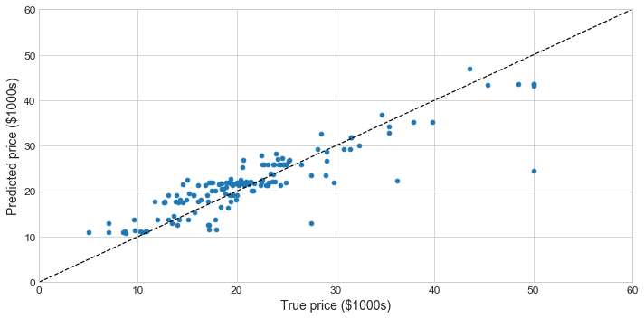

```python
Reg = 'Ada Boost Regressor'

clf = AdaBoostRegressor()
clf.fit(X_train, y_train)

# Predicted Values
Predicted = clf.predict(X_test)
# Expected Values
Expected = y_test

# the plot
Plot_Reg_Results(Expected, Predicted, Reg)

# the table
Results.loc[Reg,:] = [clf.score(X_test, y_test), mean_squared_error(Expected, Predicted),
                                      r2_score(Expected, Predicted)]
display(Results.style.background_gradient(cmap='Greens', subset=['Score']).set_precision(2))
```

## Bagging Regressor

See more about [Bagging Regressor](https://scikit-learn.org/stable/modules/generated/sklearn.ensemble.BaggingRegressor.html#sklearn.ensemble.BaggingRegressor) here.

| Regression | Score | MSE | Variance score |
| --- | --- | --- | --- |
| Ordinary Least Squares | 0.71 | 21.52 | 0.71 |
| Ridge | 0.71 | 21.54 | 0.71 |
| Lasso | 0.71 | 21.53 | 0.71 |
| Elastic-Net | 0.66 | 25.41 | 0.66 |
| Least Angle Regressions (LARS) | 0.71 | 21.52 | 0.71 |
| LARS Lasso | 0.71 | 21.62 | 0.71 |
| Orthogonal Matching Pursuit | 0.71 | 21.52 | 0.71 |
| Bayesian Regression | 0.69 | 22.73 | 0.69 |
| Huber Regressor | 0.65 | 26.38 | 0.65 |
| RANSAC | 0.64 | 27.15 | 0.64 |
| Kernel Ridge Regression | 0.67 | 24.89 | 0.67 |
| MLP Regressor | 0.65 | 26.42 | 0.65 |
| Decision Tree Regression | 0.85 | 11.01 | 0.85 |
| Gradient Boosted Tree | 0.89 | 8.14 | 0.89 |
| Ada Boost Regressor | 0.78 | 16.71 | 0.78 |
| Bagging Regressor | 0.86 | 10.35 | 0.86 |

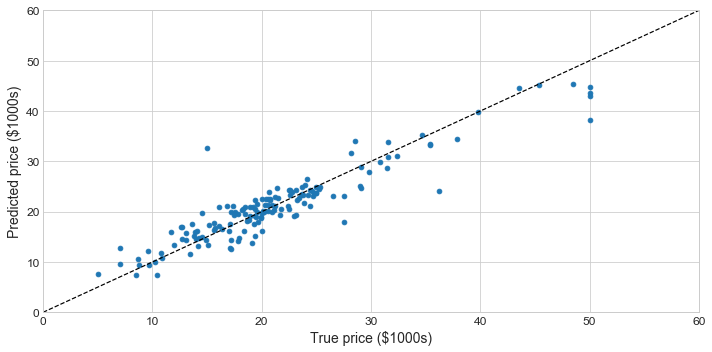

```python
Reg = 'Bagging Regressor'

clf = BaggingRegressor()
clf.fit(X_train, y_train)

# Predicted Values
Predicted = clf.predict(X_test)
# Expected Values
Expected = y_test

# the plot
Plot_Reg_Results(Expected, Predicted, Reg)

# the table
Results.loc[Reg,:] = [clf.score(X_test, y_test), mean_squared_error(Expected, Predicted),
                                      r2_score(Expected, Predicted)]
display(Results.style.background_gradient(cmap='Greens', subset=['Score']).set_precision(2))
```

## Random Forest Regressor

See more about [Random Forest Regressor](https://scikit-learn.org/stable/modules/generated/sklearn.ensemble.RandomForestRegressor.html) here.

| Regression | Score | MSE | Variance score |
| --- | --- | --- | --- |
| Ordinary Least Squares | 0.71 | 21.52 | 0.71 |
| Ridge | 0.71 | 21.54 | 0.71 |
| Lasso | 0.71 | 21.53 | 0.71 |
| Elastic-Net | 0.66 | 25.41 | 0.66 |
| Least Angle Regressions (LARS) | 0.71 | 21.52 | 0.71 |
| LARS Lasso | 0.71 | 21.62 | 0.71 |
| Orthogonal Matching Pursuit | 0.71 | 21.52 | 0.71 |
| Bayesian Regression | 0.69 | 22.73 | 0.69 |
| Huber Regressor | 0.65 | 26.38 | 0.65 |
| RANSAC | 0.64 | 27.15 | 0.64 |
| Kernel Ridge Regression | 0.67 | 24.89 | 0.67 |
| MLP Regressor | 0.65 | 26.42 | 0.65 |
| Decision Tree Regression | 0.85 | 11.01 | 0.85 |
| Gradient Boosted Tree | 0.89 | 8.14 | 0.89 |
| Ada Boost Regressor | 0.78 | 16.71 | 0.78 |
| Bagging Regressor | 0.86 | 10.35 | 0.86 |
| RandomForestRegressor | 0.87 | 9.97 | 0.87 |

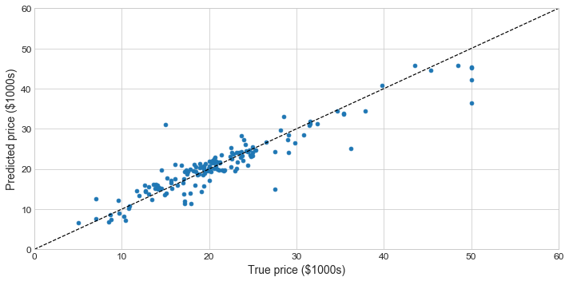

```python
Reg = 'RandomForestRegressor'

clf = RandomForestRegressor()
clf.fit(X_train, y_train)

# Predicted Values
Predicted = clf.predict(X_test)
# Expected Values
Expected = y_test

# the plot
Plot_Reg_Results(Expected, Predicted, Reg)

# the table
Results.loc[Reg,:] = [clf.score(X_test, y_test), mean_squared_error(Expected, Predicted),
                                      r2_score(Expected, Predicted)]
display(Results.style.background_gradient(cmap='Greens', subset=['Score']).set_precision(2))
```

# Conclusion

The best results in the example are coming from:

```python
Results.Score[Results.Score == Results.Score.max()].index[0]
```

```
'Gradient Boosted Tree'
```

The accuracy of predictions can vary depending on the setting that we implement in each regression.